# Literary performance by geographical region

In today’s landscape, literature is an often-overlooked medium with rich cultural traditions dating back to before recorded history. Wherever society arose, storytelling and information served to reflect its beliefs and culture. Each populated region has its own history and traditions, passed down through both oral and written texts. Over the ages, these regions have risen and declined in cultural prominence. My goal is to answer which region’s literature is the most prominent in today’s literary canon.

Here is the obtained data:

- contemporary (https://data.post45.org/posts/international-bestsellers/index.html).
- All time (https://www.kaggle.com/datasets/thedevastator/books-sales-and-ratings).

Here are some tools that I used throught the project:

```python
#!pip install pandas
#!pip install pycountry
#!pip install matplotlib
#!pip install cartopy
#!pip install geopandas
import cartopy.crs as ccrs
import cartopy.feature as cfeature
import pycountry
import matplotlib.pyplot as plt
import matplotlib.colors as mcolors
import pandas as bk
import geopandas as gpd
```

## International best sellers:

I picked this dataset to get a contemporary census on the popularity of literature worldwide. This is not a measure of writing quality or innovative techniques shown by region; this dataset shows which books are being read, and by whom they are written.

Using the contemporary dataset, I created a new dataset from the original one that includes only these relevant categories: rank, date, country, title, author, gender, and nationality. The most interesting column is rank, since it shows a book’s placement on a country’s bestseller list. To ensure consistency, I dropped every entry with a missing value (NA) for rank.

The date formatting in this dataset was in mm/dd/year, while my other datasets use only the year; therefore, I reformatted the date column to include only the year so it would match the others. Since the other datasets also include country codes, I added a code column based on the listed countries.

I also created a function to format gender consistently as either “male” or “female.” Overall, this section took the longest to clean, but the effort was worth it!

```python
df = bk.read_csv('international_bestsellers.csv')
df.columns
df_international = df[["rank", "date", "country", "title", "author", "gender", "nationality"]]
df_international = df_international.dropna(subset=["rank"])
df_international = df_international.reset_index(drop=True)
df_international["date"] = bk.to_datetime(df_international["date"], errors='coerce')
df_international["date"] = df_international["date"].dt.year

#found this method to convert country names to its country code, to format the same as other datasets
import pycountry
def get_country_code(name):
    try:
        return pycountry.countries.lookup(name).alpha_2
    except LookupError:
        return None
df_international['code'] = df_international['country'].apply(get_country_code)

#I also want the gender formatting to be the same as other datasets
def format_gender(gen):
    try:
        if gen == "w":
            return "female"
        elif gen == "m":
            return "male"
        formated = []
        multi = str(gen).split("; ")
        for g in multi:
            if g == "w":
                formated.append("female")
            elif g == "m":
                formated.append("male")
            else:
                formated.append(g)
        string = "; ".join(formated)
        return string
    except TypeError:
        return None
df_international["gender"] = df_international["gender"].apply(format_gender)
df_international
```

|  | rank | date | country | title | author | gender | nationality | code |
| --- | --- | --- | --- | --- | --- | --- | --- | --- |
| 0 | 1 | 2022 | France | The Wizard of the Kremlin | Giuliano da Empoli | male | Italy | FR |
| 1 | 1 | 2022 | Germany | Facial Expressions | Sebastian Fitzek | male | Germany | DE |
| 2 | 1 | 2022 | Italy | The House of Lights | Donato Carrisi | male | Italy | IT |
| 3 | 1 | 2022 | Spain | Waiting for the Deluge | Dolores Redondo | female | Spain | ES |
| 4 | 1 | 2022 | Egypt | Orfanelli Hall | Achraf El Achmawi | male | Egypt | EG |
| ... | ... | ... | ... | ... | ... | ... | ... | ... |
| 7904 | 10 | 2013 | Germany | The Golden Shore | Iny Lorentz | male; female | Germany | DE |
| 7905 | 10 | 2013 | Italy | I Watch You | Irene Cao | female | Italy | IT |
| 7906 | 10 | 2013 | South Korea | The Art of Thinking Clearly | Rolf Dobelli | male | Switzerland | KR |
| 7907 | 10 | 2013 | Spain | The Barefoot Queen | Ildefonso Falcones | male | Spain | ES |
| 7908 | 10 | 2013 | United States | Best Kept Secret | Jeffrey Archer | male | United Kingdom | US |

7909 rows × 8 columns

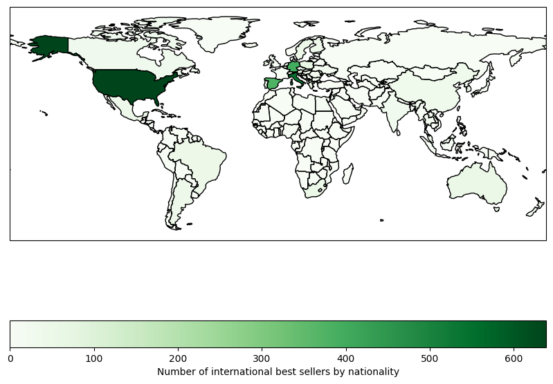

```python
best_sellers = df_international.drop_duplicates(subset=["title", "author"])
country_plots = best_sellers['code'].value_counts().to_dict()
url = "https://naciscdn.org/naturalearth/110m/cultural/ne_110m_admin_0_countries.zip"
world = gpd.read_file(url)
world = world["CONTINENT"] != "Antarctica"
world = gpd.read_file(url)[world]
world['count'] = world['ISO_A2'].map(country_plots).fillna(0).astype(int)
fig, ax = plt.subplots(figsize=(10, 10), subplot_kw={'projection': ccrs.PlateCarree()})
world.plot(column='count', ax=ax, legend=True, cmap="Greens",  edgecolor="black", legend_kwds={'label': "Number of international best sellers by nationality", 'orientation': "horizontal"})
ax.add_feature(cfeature.BORDERS, linewidth=0.5)
plt.show()
```

[figure not shown]

```python
rankings_by_year = (
    best_sellers.groupby(["code", "date"])["rank"]
    .mean()
    .reset_index()
)
mean_ranks = rankings_by_year.groupby("code")["rank"].mean()
top_codes = mean_ranks[mean_ranks <= 5].index
filtered = rankings_by_year[rankings_by_year["code"].isin(top_codes)]
pivot_rankings = filtered.pivot(index="date", columns="code", values="rank")
plt.figure(figsize=(12, 7))
for nationality in pivot_rankings.columns:
    plt.plot(pivot_rankings.index, pivot_rankings[nationality], label=nationality)
plt.gca().invert_yaxis()
plt.title("Average Bestseller Rankings by Nationality (Mean Rank ≤ 5)")
plt.xlabel("Year")
plt.ylabel("Average Rank")
plt.legend(title="Nationality", bbox_to_anchor=(1.05, 1), loc="upper left")
plt.grid(True, linestyle="--", alpha=0.6)
plt.tight_layout()
plt.show()
```

It's apperent that the main issue with this data set (shown by the graph), is that it is heavily biased towards American literature. I wouldn't say that the dataset is biased by it's self, but the whole industry instead. While the dataset used Publishing Trends, and The New York Times as sources, both American companies, both companies are highly reputable and constantly proofed checked. The dataset represents data from multiple countries' top ten. What is aperent is that American entertainment dwarfs the entertainment sectors of any other country, and is often marketed much better. This is to say that yes the dataset is biased towards American media, but this reflects a greater interest in American literature

# Top Rated Books of All Time

This dataset compiles the highest-rated literary works based on average ratings and number of reviews. Many well-known classics top the chart, but there are also some books that I had rarely heard of. To make the data usable, I selected only the most relevant columns: top_500_rank, pub_year, author_nationality, title, author, author_gender, orig_land, genre, gr_num_ratings, gr_num_reviews, gr_avg_rating_rank, and gr_num_ratings_rank. For my purposes, I filtered the dataset so that each entry has a unique title and author, along with a rank and nationality.

I made sure to filter out duplicates that share the same title and author. Then, I ensured that every book is ranked and that every author has a nationality. I also renamed some of the columns for easier readability. This dataset didn’t need much tweaking, because it was already sorted just the way I needed it.

```python
df = bk.read_csv('top-500-novels-metadata_2025-01-11.csv')
df.columns
df_top = df[["top_500_rank", "pub_year", "author_nationality", "title", "author", "author_gender", "orig_lang", "genre", "gr_num_ratings", "gr_num_reviews","gr_avg_rating_rank","gr_num_ratings_rank"]]
df_top = df_top.drop_duplicates(subset = ["title", "author"])
df_top = df_top.dropna(subset=["top_500_rank"])
df_top = df_top.dropna(subset=["author_nationality"])
df_top = df_top.reset_index(drop=True)
df_top = df_top.rename(columns={"top_500_rank": "rank", "pub_year": "year", "author_nationality": "nationality", "author_gender": "gender", "orig_lang": "language", "gr_num_ratings": "num_ratings", "gr_num_reviews": "num_reviews", "gr_avg_rating_rank": "avg_rating_rank", "gr_num_ratings_rank": "num_ratings_rank"})
df_top
```

|  | rank | year | nationality | title | author | gender | language | genre | num_ratings | num_reviews | avg_rating_rank | num_ratings_rank |
| --- | --- | --- | --- | --- | --- | --- | --- | --- | --- | --- | --- | --- |
| 0 | 1 | 1605 | ES | Don Quixote | Miguel de Cervantes | male | Spanish | action | 269435 | 12053 | 318 | 211 |
| 1 | 2 | 1865 | GB | Alice's Adventures in Wonderland | Lewis Carroll | male | English | fantasy | 561016 | 15380 | 172 | 133 |
| 2 | 3 | 1884 | US | The Adventures of Huckleberry Finn | Mark Twain | male | English | action | 1262480 | 19440 | 373 | 68 |
| 3 | 4 | 1876 | US | The Adventures of Tom Sawyer | Mark Twain | male | English | action | 931898 | 13603 | 301 | 88 |
| 4 | 5 | 1883 | GB | Treasure Island | Robert Louis Stevenson | male | English | action | 486155 | 16307 | 368 | 145 |
| ... | ... | ... | ... | ... | ... | ... | ... | ... | ... | ... | ... | ... |
| 495 | 496 | 1961 | US | Stranger in a Strange Land | Robert A. Heinlein | male | English | scifi | 311859 | 9961 | 310 | 190 |
| 496 | 497 | 2009 | US | Vision in White | Nora Roberts | female | English | romance | 138445 | 4652 | 128 | 277 |
| 497 | 498 | 1986 | US | The Whipping Boy | Sid Fleischman | male | English | action | 27444 | 1623 | 476 | 445 |
| 498 | 499 | 2010 | IE | Room | Emma Donoghue | female | English | na | 801989 | 50594 | 171 | 101 |
| 499 | 500 | 2001 | US | Deception Point | Dan Brown | male | English | political | 658866 | 10464 | 420 | 122 |

500 rows × 12 columns

Using my cleaned dataset, I created two simple bar charts that would compare the nationalities present in the top 500 novels vs the nationalities in the top 10. I'm going to have to create two seperate plots and then assing them to an axis of a figuire. In the first plot, I found the count for each nationality in the dataset. Then I only grab the top ten most frequentm and I plotted them. In the second, I filtered the top ten ranked of the dataset and I got their nationality count.

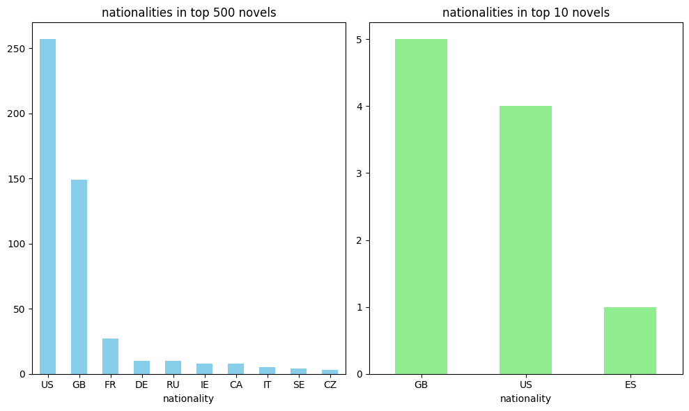

```python
nat_count = df_top["nationality"].value_counts()
fig, (ax1, ax2) = plt.subplots(1, 2, figsize=(18, 6))
top_all = nat_count.head(10).plot(kind='bar', color='skyblue', figsize=(10, 6), ax=ax1)
ax1.set_title("nationalities in top 500 novels")
top_ten = df_top[df_top["rank"] <= 10]["nationality"].value_counts()
top_ten_count = top_ten.plot(kind='bar', color='lightgreen', figsize=(10, 6), ax=ax2)
ax2.set_title("nationalities in top 10 novels")
ax1.tick_params(axis='x', rotation=0)
ax2.tick_params(axis='x', rotation=0)
plt.tight_layout()
plt.show()
```

Here I will do the same type of comperison but with language of origin.

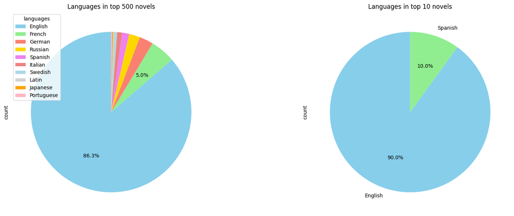

```python
lang_count = df_top["language"].value_counts()
fig, (ax1, ax2) = plt.subplots(1, 2, figsize=(18, 6))
def my_pct(pct):
    if pct >= 5:
        return f'{pct:.1f}%'
    return ''
slice_colors = ["skyblue", "lightgreen", "salmon", "gold", "violet", "lightcoral", "lightblue", "lightgrey", "orange", "lightpink"]
top_all = lang_count.head(10)
top_all = lang_count.head(10).plot(kind='pie', labels=None, autopct=my_pct, startangle=90, ax=ax1,
    colors=slice_colors)
ax1.set_title("Languages in top 500 novels")
top_ten = df_top[df_top["rank"] <= 10]["language"].value_counts()
top_ten_count = top_ten.plot(kind='pie', autopct='%1.1f%%', startangle=90, ax=ax2,
    colors=slice_colors)
ax2.set_title("Languages in top 10 novels")
ax1.legend(lang_count.index, title="languages", loc="best")
plt.tight_layout()
plt.show()
```

When it comes to quantity, American publications top the list. When it comes to quality, European countries outnumber the North Americans. This to say that American publication is much more recognized on avarage, but does not hold the same level prestige as some of the older countries. Canada and Mexico does have a few notable works in the list, but if we are looking for the strongest literary scene it would be in Europe

# Conclusion

Through this project, I set out to understand which regions dominate the global literary landscape today and how that compares to historically significant works. By cleaning and analyzing two complementary datasets, contemporary bestsellers and long-term sales/ratings, I was able to highlight both the strengths and limitations of global representation in literature. Ultimately, the findings reveal not only which regions are most prominent, but also how market forces, cultural history, and institutional biases shape the stories that reach readers worldwide. While this study cannot capture the full diversity of global literary traditions, it underscores the importance of broadening our data sources and perspectives if we hope to gain a more balanced view of world literature.